# Data Mining 07/14

## Data Visualization

0. R project 단위로 작업하기
1. 한글 사용: Tools > Global Options > Code > Saving > UTF-8로 설정

데이터 시각화는 분석의 기초입니다. EDA (Exploratory Data Analysis) kaggle.com 사이트에서 데이터 분석에 대한 다양한 분석 결과와 EDA 시도를 볼 수 있습니다.

방대한 양의 자료가 명확한 분석 주제 없이 단순히 주어졌을 때, 의미있는 정보를 찾아낼 수 있을까? "Data Mining"

그리고 싶은 모양을 상상하고, 구체적인 코드는 key word를 이용해 Google에 검색합니다. 이를 위해서는 어떤 그림을 그릴 수 있는지, 뭐라고 검색해야하는지 기본적으로 알아야 합니다.

```r
data(iris)
head(iris)
```

```
##   Sepal.Length Sepal.Width Petal.Length Petal.Width Species
## 1          5.1         3.5          1.4         0.2  setosa
## 2          4.9         3.0          1.4         0.2  setosa
## 3          4.7         3.2          1.3         0.2  setosa
## 4          4.6         3.1          1.5         0.2  setosa
## 5          5.0         3.6          1.4         0.2  setosa
## 6          5.4         3.9          1.7         0.4  setosa
```

```r
str(iris)
```

```
## 'data.frame':    150 obs. of  5 variables:
##  $ Sepal.Length: num  5.1 4.9 4.7 4.6 5 5.4 4.6 5 4.4 4.9 ...
##  $ Sepal.Width : num  3.5 3 3.2 3.1 3.6 3.9 3.4 3.4 2.9 3.1 ...
##  $ Petal.Length: num  1.4 1.4 1.3 1.5 1.4 1.7 1.4 1.5 1.4 1.5 ...
##  $ Petal.Width : num  0.2 0.2 0.2 0.2 0.2 0.4 0.3 0.2 0.2 0.1 ...
##  $ Species     : Factor w/ 3 levels "setosa","versicolor",..: 1 1 1 1 1 1 1 1 1 1 ...
```

R을 이용해 데이터를 그려보는 함수는 내장 plot을 쓰는 것과 외부 패키지인 ggplot이 있습니다.

Basic1.rmd 파일에서 두 함수를 비교하고 iris 데이터에 대한 분석을 진행해 봅니다.

## Statistical Inference

우리가 모집단에 대해 전반적인 조사를 할 수 없을 때, 표본에서 정보를 추출합니다. 실험 조사에서 "Random Sampling"이 중요한 이유는, 잘 뽑은 표본은 그 크기가 아주 작아도 모집단에 대한 정보를 거의 대부분 담고 있기 때문입니다.

커피에 시럽 농도가 우리의 관심사라고 할 때 잘 섞인 커피는 한 입만 마시고도 농도에 대한 정확한 정보를 알 수 있지만 시럽이 하나도 섞이지 않은 경우 90% 이상의 커피를 마셔도 그 농도에 대해 부정확하게 이해를 할 수 밖에 없는 원리입니다.

경제 자료에 대한 데이터를 포함하는 'quantmod' 패키지에서 KOSPI 자료를 얻을 수 있습니다.

```r
#install.packages("quantmod")
library(quantmod)
options("getSymbols.warning4.0"=FALSE)
samsung = getSymbols("005930.KS",auto.assign = FALSE)
head(samsung)
```

```
##            005930.KS.Open 005930.KS.High 005930.KS.Low 005930.KS.Close
## 2007-01-02          12400          12540         12320           12520
## 2007-01-03          12540          12560         12220           12280
## 2007-01-04          12220          12240         12060           12120
## 2007-01-05          12160          12180         11900           11900
## 2007-01-08          11840          11880         11580           11680
## 2007-01-09          11740          11880         11640           11720
##            005930.KS.Volume 005930.KS.Adjusted
## 2007-01-02         17607300           0.329870
## 2007-01-03         19676500           0.323546
## 2007-01-04         18258900           0.319331
## 2007-01-05         28400400           0.313534
## 2007-01-08         33081550           0.307738
## 2007-01-09         20109850           0.308792
```

```r
samsung['2008-09-08/2008-09-15']
```

```
##            005930.KS.Open 005930.KS.High 005930.KS.Low 005930.KS.Close
## 2008-09-08          10660          11020         10620           10860
## 2008-09-09          10800          10800         10600           10720
## 2008-09-10          10440          10960         10400           10840
## 2008-09-11          10900          11140         10720           10740
## 2008-09-12          10880          11000         10780           10860
## 2008-09-15          10860          10860         10860           10860
##            005930.KS.Volume 005930.KS.Adjusted
## 2008-09-08         38900200           0.890302
## 2008-09-09         22013050           0.878825
## 2008-09-10         36506850           0.888662
## 2008-09-11         47173400           0.880464
## 2008-09-12         30258700           0.890302
## 2008-09-15                0           0.890302
```

많은 경우 우리는 가격 자체보다 return 값에 관심있는데요, 이론적 이유로 우리는 "log returns"를 봅니다.
$$R_t = \log {(P_t/P_{t-1})}$$

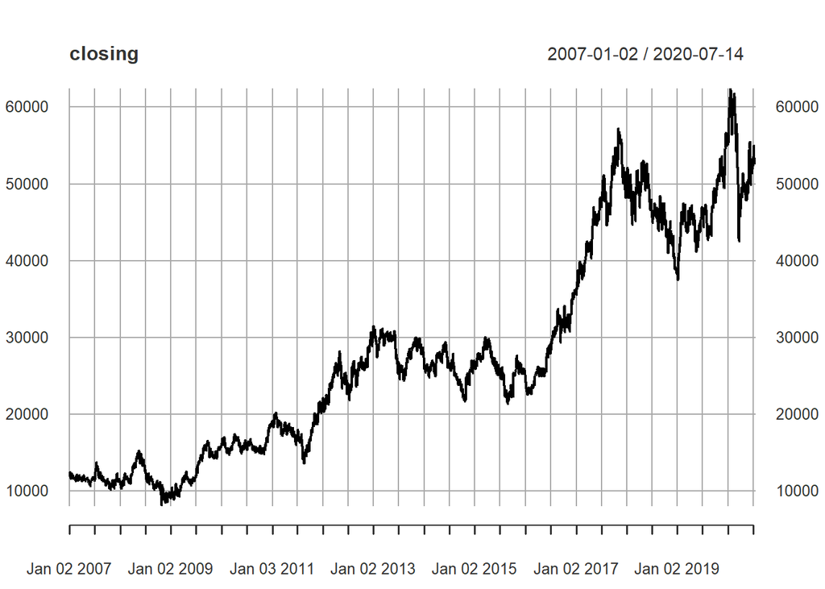

```r
closing<-samsung[,4]
plot(closing)
```

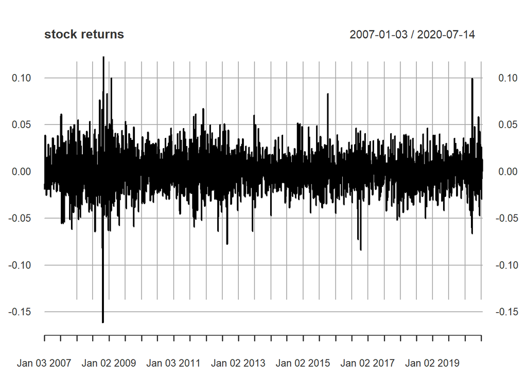

```r
samsung.ret <- diff(log(closing))
samsung.ret <- samsung.ret[-1] # remove NA in the 1st place
plot(samsung.ret, main="stock returns",type='l')
```

```r
ret <- as.vector(samsung.ret) # from xts to numeric
which(is.na(ret))
```

```
##  [1] 2702 2703 2707 2708 2731 2732 2944 2945 3189 3190
```

```r
ret = ret[-which(is.na(ret))]
```

```r
summary(ret)
```

```
##       Min.    1st Qu.     Median       Mean    3rd Qu.       Max.
## -0.1615857 -0.0104326  0.0000000  0.0004241  0.0110421  0.1226833
```

One reason that we use log return is that there's a nice theory on stock prices assuming the log return is normally distributed

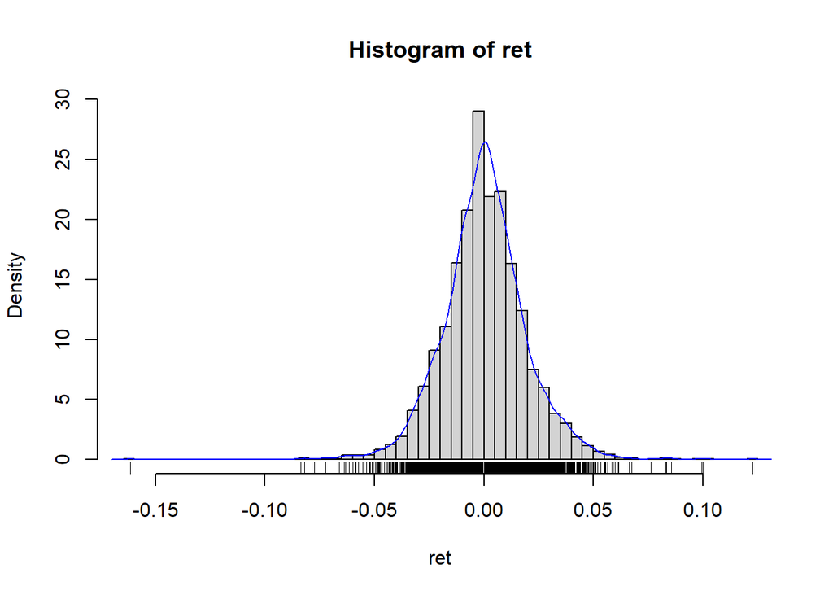

```r
hist(ret,breaks=100, prob=TRUE)
lines(density(ret),col="blue")
rug(ret)
```

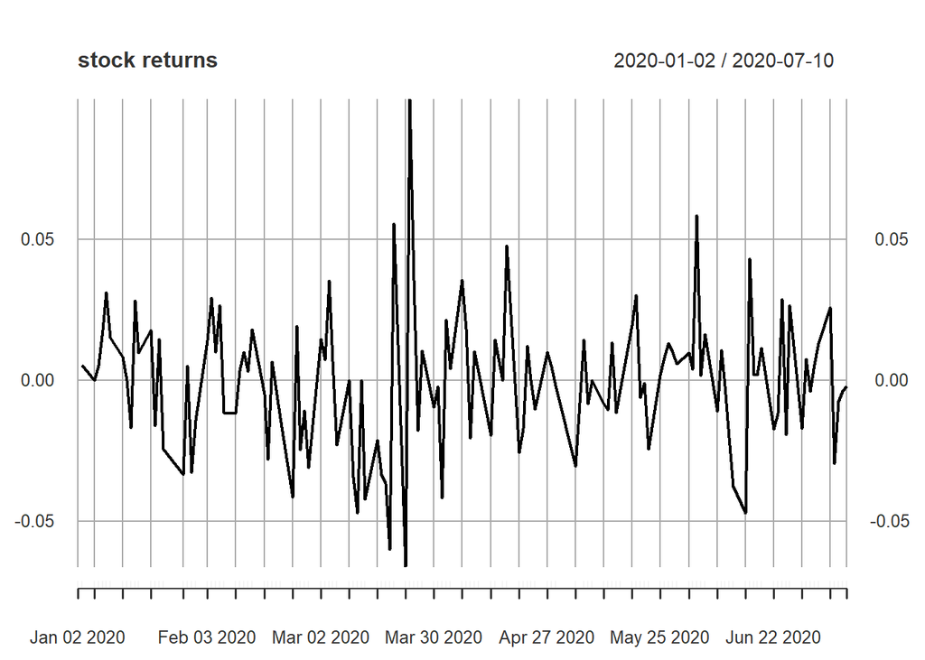

```r
samsung.ret20 <- diff(log(samsung['2020-01-01/2020-07-10']$`005930.KS.Close`))
plot(samsung.ret20, main="stock returns",type='l')
```

```r
ret20 <- as.vector(samsung.ret20) # from xts to numeric
summary(ret20)
```

```
##       Min.    1st Qu.     Median       Mean    3rd Qu.       Max.       NA's
## -0.0660080 -0.0156378  0.0009166 -0.0003565  0.0128610  0.0995791          1
```

```r
stem(ret20)
```

```
##
##   The decimal point is 2 digit(s) to the left of the |
##
##   -6 | 60
##   -5 |
##   -4 | 77221
##   -3 | 874333100
##   -2 | 864443100
##   -1 | 998777764322211100
##   -0 | 988865443322221
##    0 | 0000000222233344555566777888
##    1 | 00000000112333444555688889
##    2 | 02677899
##    3 | 01566
##    4 | 38
##    5 | 59
##    6 |
##    7 |
##    8 |
##    9 |
##   10 | 0
```